# 1. Datos en R

FES Acatlán

agosto de 2021

Limpiar área de trabajo

```r
rm(list=ls())
```

## Datos en R

Existen distintas formas de guardar valores en un objeto en *R* dependiendo el prop?sito

- Vectores
- Matrices
- Arrays
- Data Frames (tablas / datasets)
- Listas
- Series de tiempo (objeto especializado, fuera del alcance de este curso)

Los valores en R pueden ser de 4 tipos

- númericos (decimal y entero)
- carácter
- lógico (Booleano)
- factor (Es un tipo especial de carácter. Se puede considerar como una variable ordinal)

### Vectores

Objetos unidimencionales de longitud finita. Los elementos de un vector sólo pueden ser de un tipo

```r
vector1 <- c(1,2,3,4,5,6,7,8,9)   # se utiliza la c para concatenar valores
vector2 <- 9:1                    # los 2 puntos se usan para generar secuencias de numeros consecutivos
```

```r
vector1
```

```
## [1] 1 2 3 4 5 6 7 8 9
```

```r
vector2
```

```
## [1] 9 8 7 6 5 4 3 2 1
```

```r
vector3 <- seq(from=-3,to=6, by = 1)
# si se conoce la longitud deseada se puede usar el parámetro length.out
vector3a <- seq(from= -3, to= 6, length.out = 101)

# repetir el valor 1 cinco veces
# help(rep)
vector4 <- rep(1,5)
```

```r
vector3
```

```
##  [1] -3 -2 -1  0  1  2  3  4  5  6
```

```r
vector3a
```

```
##   [1] -3.00 -2.91 -2.82 -2.73 -2.64 -2.55 -2.46 -2.37 -2.28 -2.19 -2.10
##  [12] -2.01 -1.92 -1.83 -1.74 -1.65 -1.56 -1.47 -1.38 -1.29 -1.20 -1.11
##  [23] -1.02 -0.93 -0.84 -0.75 -0.66 -0.57 -0.48 -0.39 -0.30 -0.21 -0.12
##  [34] -0.03  0.06  0.15  0.24  0.33  0.42  0.51  0.60  0.69  0.78  0.87
##  [45]  0.96  1.05  1.14  1.23  1.32  1.41  1.50  1.59  1.68  1.77  1.86
##  [56]  1.95  2.04  2.13  2.22  2.31  2.40  2.49  2.58  2.67  2.76  2.85
##  [67]  2.94  3.03  3.12  3.21  3.30  3.39  3.48  3.57  3.66  3.75  3.84
##  [78]  3.93  4.02  4.11  4.20  4.29  4.38  4.47  4.56  4.65  4.74  4.83
##  [89]  4.92  5.01  5.10  5.19  5.28  5.37  5.46  5.55  5.64  5.73  5.82
## [100]  5.91  6.00
```

```r
vector4
```

```
## [1] 1 1 1 1 1
```

Una ventaja de usar vectores con *R*, es la vectorización de elementos

`Ejercicio`. ¿Qué resultados podríamos esperar al realizar las siguientes operaciones?

1. sumar los vectores 1 y 2
2. sumar los vectores 4 y 1

```r
vector1 + vector2
```

```
## [1] 10 10 10 10 10 10 10 10 10
```

```r
vector4 + vector1     ## Al ser de distinta longitud, recicla los valores
```

```
## [1]  2  3  4  5  6  7  8  9 10
```

Notar que la suma de vectores se hace elemento a elemento.

Es útil conocer la longitud de los vectores

```r
length(vector1)
```

```
## [1] 9
```

```r
length(vector4)
```

```
## [1] 5
```

Se pueden unir varios vectores para formar uno nuevo

```r
vector5 <- c(vector3,vector4)
vector5
```

```
##  [1] -3 -2 -1  0  1  2  3  4  5  6  1  1  1  1  1
```

Ejemplo de vector con valores tipo carácter

```r
vector6 <- c("H","M")
vector6
```

```
## [1] "H" "M"
```

`Ejercicio`. Intentar creear 1 vector con 2 tipos distintos de elementos.

```r
vector_mix <- c(1,"H")
```

```r
# Recordemos los valores guardados en los primeros 2 vectores
vector1
```

```
## [1] 1 2 3 4 5 6 7 8 9
```

```r
vector2
```

```
## [1] 9 8 7 6 5 4 3 2 1
```

La función módulo en R es con 2 signos de porcentaje (%). Combinar la función módulo con el número 2, es útil para saber si un número es par o impar

```r
vector1 %% 2
```

```
## [1] 1 0 1 0 1 0 1 0 1
```

`Ejercicio`

1. obtener la suma de todos los elementos del vector1
2. obtener el minimo del vector2
3. comparar el vector1 con el vector2 y obtener el m?nimo de entrada por entrada

```r
sum(vector1)
```

```
## [1] 45
```

```r
min(vector2)
```

```
## [1] 1
```

```r
pmin(vector1,vector2)       # útil cuando se quiere hacer algo como el minimo entre un valor y  un número fijo, digamos 12
```

```
## [1] 1 2 3 4 5 4 3 2 1
```

Suma de un vector más un escalar. Multiplicación de un vector por un escalar.

```r
vector1 + 5
```

```
## [1]  6  7  8  9 10 11 12 13 14
```

```r
2 * vector1
```

```
## [1]  2  4  6  8 10 12 14 16 18
```

### Matrices

Objetos bidimencionales

```r
matriz1 <- matrix(vector1,nrow = 3, ncol = 3) #si sólo se asigna un par?metro de las dimensiones, el otro se ajusta en automático
matriz1
```

```
##      [,1] [,2] [,3]
## [1,]    1    4    7
## [2,]    2    5    8
## [3,]    3    6    9
```

```r
matriz2 <- matrix(vector1,nrow = 3, ncol = 3, byrow = TRUE) #si se desea los valores de la matriz sean llenados de forma horizontal se usa un parámetro adicional
matriz2
```

```
##      [,1] [,2] [,3]
## [1,]    1    2    3
## [2,]    4    5    6
## [3,]    7    8    9
```

Para conocer las dimensiones de la matriz se usa la función dim. El resultado es un vector de 2 elementos, el primero indica el número de filas y el segundo el número de columnas

```r
dim(matriz1)
```

```
## [1] 3 3
```

Nota. Los vectores tienen una sola dimensión y en *R* se le llama longitud.

Existen funciones creadas especialmente para matrices y vectores por el enfoque estadístico de *R*

Crear una matriz diagonal

```r
matriz3 <- diag(c(2,2,2))
matriz3
```

```
##      [,1] [,2] [,3]
## [1,]    2    0    0
## [2,]    0    2    0
## [3,]    0    0    2
```

Multiplicar matrices. La multiplicación de matrices se realiza con el operador %*%

```r
# Nota. El número de columnas de la matriz izquierda debe ser igual al numero de filas de la matriz derecha
matriz1 %*% matriz3
```

```
##      [,1] [,2] [,3]
## [1,]    2    8   14
## [2,]    4   10   16
## [3,]    6   12   18
```

### Arrays

Objetos n dimencionales

```r
arreglo1 <- array(c(matriz1,matriz2,matriz3),dim=c(3,3,3))
arreglo1
```

```
## , , 1
##
##      [,1] [,2] [,3]
## [1,]    1    4    7
## [2,]    2    5    8
## [3,]    3    6    9
##
## , , 2
##
##      [,1] [,2] [,3]
## [1,]    1    2    3
## [2,]    4    5    6
## [3,]    7    8    9
##
## , , 3
##
##      [,1] [,2] [,3]
## [1,]    2    0    0
## [2,]    0    2    0
## [3,]    0    0    2
```

```r
dim(arreglo1)
```

```
## [1] 3 3 3
```

### Data Frames (Marco de datos)

Serán los principales objetos de interés. Son tablas de datos. Los data frames permiten tener columnas con distinto tipo de datos.

Antes de crear nuestro primer data frame, veremos otra funcionalidad de *R*: crear valores aleatorios

La función *rnorm*, genera valores aleatorios de una distribución normal, utiliza 3 parámetros:

- n: número de valores a generar
- mean: media (promedio)
- sd: desviación estándar

```r
set.seed(1234)
altura <- rnorm(n=30,mean=165,sd=10)
altura
```

```
##  [1] 152.9293 167.7743 175.8444 141.5430 169.2912 170.0606 159.2526
##  [8] 159.5337 159.3555 156.0996 160.2281 155.0161 157.2375 165.6446
## [15] 174.5949 163.8971 159.8899 155.8880 156.6283 189.1584 166.3409
## [22] 160.0931 160.5945 169.5959 158.0628 150.5180 170.7476 154.7634
## [29] 164.8486 155.6405
```

¿Por qué se fijó una semilla en el bloque de código anterior?. Respuesta: Fijar la semilla para que el proceso sea replicable.

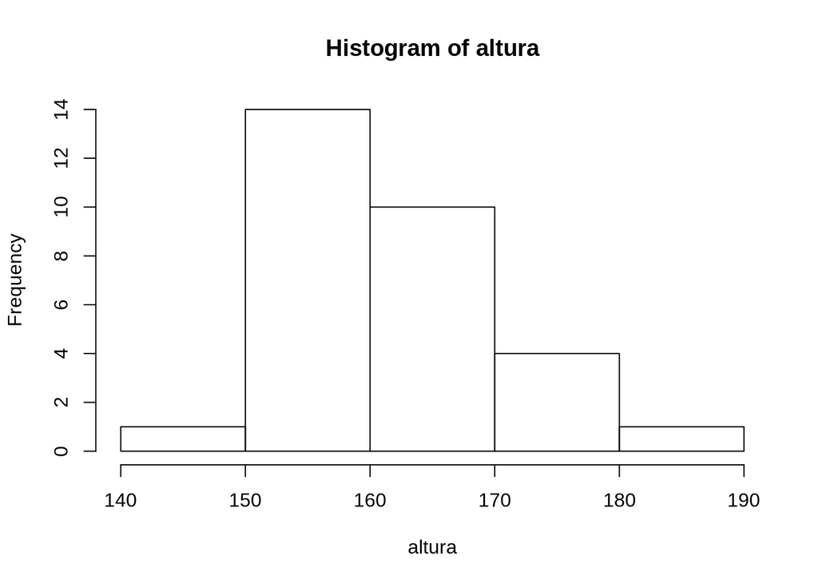

```r
# Graficar de manera muy sencilla
hist(altura)
```

**La siguiente función es fundamental para el muestreo**

La función *runif* genera valores aleatorios de una distribución uniforme. Utilza 3 parámetros:

- n: número de valores a generar
- min: valor mínimo
- max: valor máximo

```r
#fijar la semilla para ue el proceso sea replicable
set.seed(1234)
peso <- runif(n=30,min=50,max=85)
peso
```

```
##  [1] 53.97962 71.78048 71.32462 71.81828 80.13204 72.41087 50.33235
##  [8] 58.13927 73.31293 67.99879 74.27570 69.07412 59.89568 82.32017
## [15] 60.23105 79.30535 60.01781 59.33873 56.53530 58.12791 61.08144
## [22] 60.59427 55.56661 51.39986 57.65798 78.37095 68.39941 82.01304
## [29] 79.09708 51.60196
```

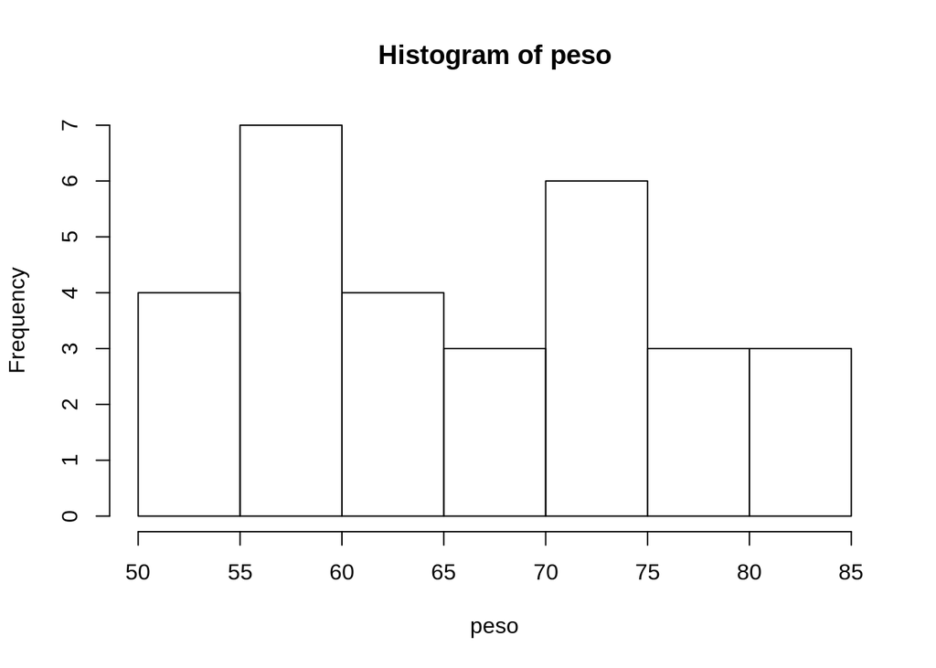

```r
hist(peso)
```

Nota. Si se omite el segundo y tercer parámetro en las 2 funciones anteriores, se generan valores con los parámetros por default. Para la normal son mean = 0 y sd = 1; para la uniforme son min = 0 y max = 1.

Recordar. Toda vez que se usen valores aleatorios o funciones que involucren valores aleatorios, establecer una semilla para que el proceso sea replicable.

`Ejemplo`. Crear un data frame

En general, los data frames los usamos al importar datos de otra fuente, pocas veces se crean desde cero.

```r
tabla1 <- data.frame(altura1=altura,peso1=peso) # por conveniencia repetimos los nombres, pero pueden ser arbitrarios
tabla1
```

```
##     altura1    peso1
## 1  152.9293 53.97962
## 2  167.7743 71.78048
## 3  175.8444 71.32462
## 4  141.5430 71.81828
## 5  169.2912 80.13204
## 6  170.0606 72.41087
## 7  159.2526 50.33235
## 8  159.5337 58.13927
## 9  159.3555 73.31293
## 10 156.0996 67.99879
## 11 160.2281 74.27570
## 12 155.0161 69.07412
## 13 157.2375 59.89568
## 14 165.6446 82.32017
```

[output cut: 16 more lines]

Estructura de la tabla

```r
dim(tabla1)
```

```
## [1] 30  2
```

```r
names(tabla1)
```

```
## [1] "altura1" "peso1"
```

```r
str(tabla1)
```

```
## 'data.frame':    30 obs. of  2 variables:
##  $ altura1: num  153 168 176 142 169 ...
##  $ peso1  : num  54 71.8 71.3 71.8 80.1 ...
```

`Ejercicio`. Generar un data frame sin especificar los nombres e imprimir en pantalla

```r
tabla2 <- data.frame(altura,peso)
tabla2
```

```
##      altura     peso
## 1  152.9293 53.97962
## 2  167.7743 71.78048
## 3  175.8444 71.32462
## 4  141.5430 71.81828
## 5  169.2912 80.13204
## 6  170.0606 72.41087
## 7  159.2526 50.33235
## 8  159.5337 58.13927
## 9  159.3555 73.31293
## 10 156.0996 67.99879
## 11 160.2281 74.27570
## 12 155.0161 69.07412
## 13 157.2375 59.89568
## 14 165.6446 82.32017
```

[output cut: 16 more lines]

### Listas

Las *listas* son objetos que son colección de objetos

```r
lista1 <-list(vector6,matriz3,tabla1)
lista1
```

```
## [[1]]
## [1] "H" "M"
##
## [[2]]
##      [,1] [,2] [,3]
## [1,]    2    0    0
## [2,]    0    2    0
## [3,]    0    0    2
##
## [[3]]
##     altura1    peso1
## 1  152.9293 53.97962
## 2  167.7743 71.78048
## 3  175.8444 71.32462
## 4  141.5430 71.81828
```

[output cut: 26 more lines]

```r
lista2 <-list(uno=vector6, dos=matriz3, tres=tabla1)
lista2
```

```
## $uno
## [1] "H" "M"
##
## $dos
##      [,1] [,2] [,3]
## [1,]    2    0    0
## [2,]    0    2    0
## [3,]    0    0    2
##
## $tres
##     altura1    peso1
## 1  152.9293 53.97962
## 2  167.7743 71.78048
## 3  175.8444 71.32462
## 4  141.5430 71.81828
```

[output cut: 26 more lines]

```r
names(lista1)
```

[output not shown]

```r
names(lista2)
```

```
## [1] "uno"  "dos"  "tres"
```

Notar los simbolos de pesos que anteceden a las palabras: uno, dos, tres; en la siguiente sección tomarán sentido

Es importante saber el tipo de objeto para saber como utilizar un objeto, en nuestros ejemplos sabemos que tipo de objeto son,pero cuando se obtiene un objeto como resultado de funciones que programa alguien más, podemos saber el tipo de objeto con la función class

```r
class(lista1)
```

```
## [1] "list"
```

```r
class(tabla1)
```

```
## [1] "data.frame"
```

```r
class(arreglo1)
```

```
## [1] "array"
```

```r
class(matriz1)
```

```
## [1] "matrix"
```

```r
class(vector1)
```

```
## [1] "numeric"
```

Dependiendo de las necesidades que se tengan para cierto problema, se puede convertir un objeto a otro tipo, del mismo modo se puede convertir el tipo de dato a otro tipo.

```r
as.vector(arreglo1)
```

```
##  [1] 1 2 3 4 5 6 7 8 9 1 4 7 2 5 8 3 6 9 2 0 0 0 2 0 0 0 2
```

```r
as.character(vector1)
```

```
## [1] "1" "2" "3" "4" "5" "6" "7" "8" "9"
```

### Operadores de comparación

```
* > : mayor
* < : menor
* == : igual (para evitar confundir una asignaci?n, R usa un doble igual para comparar)
* ! : distinto, este simbolo se puede combinar con funciones
* | : o (or), el simbolo es un pipe
* & : y (and), el simbolo es un ampersand
```

`Ejemplos`

```r
vector3
```

```
##  [1] -3 -2 -1  0  1  2  3  4  5  6
```

```r
vector3 > 0
```

```
##  [1] FALSE FALSE FALSE FALSE  TRUE  TRUE  TRUE  TRUE  TRUE  TRUE
```

El resultado es un vector con valores lógicos TRUE & FALSE, si estos valores son usados para operaciones aritmeticas, son considerados como ceros y unos. Nostros les daremos otra utilidad a los vectores de valores lógicos.

```r
vector1 == vector2
```

```
## [1] FALSE FALSE FALSE FALSE  TRUE FALSE FALSE FALSE FALSE
```

```r
vector1
```

```
## [1] 1 2 3 4 5 6 7 8 9
```

```r
vector1 != 1
```

```
## [1] FALSE  TRUE  TRUE  TRUE  TRUE  TRUE  TRUE  TRUE  TRUE
```

```r
matriz1 == matriz2
```

```
##       [,1]  [,2]  [,3]
## [1,]  TRUE FALSE FALSE
## [2,] FALSE  TRUE FALSE
## [3,] FALSE FALSE  TRUE
```

### Valores Ausentes (Missing Values)

Los valores missing en *R* son asignados a un c?racter especial: NA (Not Avaliable). Existe un segundo tipo de missing que es originado por computaciones númericas, es : NaN (Not a Number).

Para propósitos prácticos, ambos casos son missing y son tratados por igual

`Ejemplos`

```r
x <- c(1,2,3,4,5,NA)
x
```

```
## [1]  1  2  3  4  5 NA
```

Identificar que valores son missing

```r
x == NA #esta instrucción no realiza lo que necesitamos, le asigna a cada elemento el valor NA. Notar que incluso el editor nos señala un warning.
```

```
## [1] NA NA NA NA NA NA
```

Deseamos un vector lógico

```r
is.na(x)
```

```
## [1] FALSE FALSE FALSE FALSE FALSE  TRUE
```

En caso de querer identificar los casos que no son NA

```r
!is.na(x) #se usa el simbolo de exclamación
```

```
## [1]  TRUE  TRUE  TRUE  TRUE  TRUE FALSE
```

Segundo tipo de missing

```r
0/0
```

```
## [1] NaN
```

```r
Inf-Inf
```

```
## [1] NaN
```

### índices

Por medio de indice podemos acceder a elementos particulares de los objetos de R (los índices son sólo una opción, hay más opciones).

Nota. A diferencia de *Python*, los indices en *R* inician en 1

En vectores se usan corchetes (brackets)

```r
# Tomar el sexto valor
vector1[6]
```

```
## [1] 6
```

```r
# Tomar todo el vector a excepción de la segunda posición
vector1[-2]
```

```
## [1] 1 3 4 5 6 7 8 9
```

```r
# Tomar la primera, tercera y quinta posición
vector2[c(1,3,5)]
```

```
## [1] 9 7 5
```

`Ejercicio`. Seleccionar los elementos que sean mayores a 5

```r
# opción 1
vector2
```

```
## [1] 9 8 7 6 5 4 3 2 1
```

```r
vector2[vector2>5]
```

```
## [1] 9 8 7 6
```

```r
#opción 2 (y en particular mi preferida por sintaxis)
filtro1 <- (vector1 > 5)
filtro1 # vector lógico que nos indica que posiciones cumplen la condición
```

```
## [1] FALSE FALSE FALSE FALSE FALSE  TRUE  TRUE  TRUE  TRUE
```

```r
vector1[filtro1]
```

```
## [1] 6 7 8 9
```

Por medio de índices también se pueden reemplazar valores de un objeto

```r
vector2
```

```
## [1] 9 8 7 6 5 4 3 2 1
```

```r
vector2[1] <- 1
vector2[6] <-NA
vector2
```

```
## [1]  1  8  7  6  5 NA  3  2  1
```

Precaución, los operadores de comparación no funcionan con los NA

```r
vector2 > 3
```

```
## [1] FALSE  TRUE  TRUE  TRUE  TRUE    NA FALSE FALSE FALSE
```

```r
vector2[vector2 > 3]
```

```
## [1]  8  7  6  5 NA
```

Ejemplos con Matrices y objetos de más de una dimensión. Al igual que con los vectores se pueden acceder a los valores de objetos por medio del uso de corchetes.

```r
matriz1
```

```
##      [,1] [,2] [,3]
## [1,]    1    4    7
## [2,]    2    5    8
## [3,]    3    6    9
```

```r
matriz1[2,3]
```

```
## [1] 8
```

Se puede notar que se usan 2 índices, el primero indica el número de fila y el segundo el número de columna

Extraer la primera y tercera fila y todas las columnas

```r
matriz1[c(1,3),]  #El truco aquí es omitir el segundo índice
```

```
##      [,1] [,2] [,3]
## [1,]    1    4    7
## [2,]    3    6    9
```

### Segunda opción de acceder a datos particulares de los elementos en R

Si el objeto tiene nombres asignados para ciertos elementos, podemos hacer referencia a ellos por medio del simbolo de pesos ($)

```r
tabla1
```

```
##     altura1    peso1
## 1  152.9293 53.97962
## 2  167.7743 71.78048
## 3  175.8444 71.32462
## 4  141.5430 71.81828
## 5  169.2912 80.13204
## 6  170.0606 72.41087
## 7  159.2526 50.33235
## 8  159.5337 58.13927
## 9  159.3555 73.31293
## 10 156.0996 67.99879
## 11 160.2281 74.27570
## 12 155.0161 69.07412
## 13 157.2375 59.89568
## 14 165.6446 82.32017
```

[output cut: 16 more lines]

Acceder al vector que indica la altura

```r
tabla1$altura1
```

```
##  [1] 152.9293 167.7743 175.8444 141.5430 169.2912 170.0606 159.2526
##  [8] 159.5337 159.3555 156.0996 160.2281 155.0161 157.2375 165.6446
## [15] 174.5949 163.8971 159.8899 155.8880 156.6283 189.1584 166.3409
## [22] 160.0931 160.5945 169.5959 158.0628 150.5180 170.7476 154.7634
## [29] 164.8486 155.6405
```

```r
filtro.altura <- tabla1$altura1 > 150 &  tabla1$altura1 < 170
filtro.altura
```

```
##  [1]  TRUE  TRUE FALSE FALSE  TRUE FALSE  TRUE  TRUE  TRUE  TRUE  TRUE
## [12]  TRUE  TRUE  TRUE FALSE  TRUE  TRUE  TRUE  TRUE FALSE  TRUE  TRUE
## [23]  TRUE  TRUE  TRUE  TRUE FALSE  TRUE  TRUE  TRUE
```

```r
sum(filtro.altura)
```

```
## [1] 24
```

```r
tabla1$altura1[filtro.altura]
```

```
##  [1] 152.9293 167.7743 169.2912 159.2526 159.5337 159.3555 156.0996
##  [8] 160.2281 155.0161 157.2375 165.6446 163.8971 159.8899 155.8880
## [15] 156.6283 166.3409 160.0931 160.5945 169.5959 158.0628 150.5180
## [22] 154.7634 164.8486 155.6405
```

```r
# tabla 1 con filtro
tabla1[filtro.altura,]
```

```
##     altura1    peso1
## 1  152.9293 53.97962
## 2  167.7743 71.78048
## 5  169.2912 80.13204
## 7  159.2526 50.33235
## 8  159.5337 58.13927
## 9  159.3555 73.31293
## 10 156.0996 67.99879
## 11 160.2281 74.27570
## 12 155.0161 69.07412
## 13 157.2375 59.89568
## 14 165.6446 82.32017
## 16 163.8971 79.30535
## 17 159.8899 60.01781
## 18 155.8880 59.33873
## 19 156.6283 56.53530
## 21 166.3409 61.08144
## 22 160.0931 60.59427
## 23 160.5945 55.56661
## 24 169.5959 51.39986
## 25 158.0628 57.65798
## 26 150.5180 78.37095
## 28 154.7634 82.01304
## 29 164.8486 79.09708
## 30 155.6405 51.60196
```

```r
# tabla con filtro
tabla3 <- tabla1[c(14,14,15,15),]
tabla3
```

```
##       altura1    peso1
## 14   165.6446 82.32017
## 14.1 165.6446 82.32017
## 15   174.5949 60.23105
## 15.1 174.5949 60.23105
```

```r
row.names(tabla3)
```

```
## [1] "14"   "14.1" "15"   "15.1"
```

Otros ejemplos de acceder a los elementos de un objeto

```r
tabla1[1,2]
```

```
## [1] 53.97962
```

```r
tabla1[1,]
```

```
##    altura1    peso1
## 1 152.9293 53.97962
```

Ejemplo con listas

```r
lista2
```

```
## $uno
## [1] "H" "M"
##
## $dos
##      [,1] [,2] [,3]
## [1,]    2    0    0
## [2,]    0    2    0
## [3,]    0    0    2
##
## $tres
##     altura1    peso1
## 1  152.9293 53.97962
## 2  167.7743 71.78048
## 3  175.8444 71.32462
## 4  141.5430 71.81828
```

[output cut: 26 more lines]

```r
lista2$tres
```

```
##     altura1    peso1
## 1  152.9293 53.97962
## 2  167.7743 71.78048
## 3  175.8444 71.32462
## 4  141.5430 71.81828
## 5  169.2912 80.13204
## 6  170.0606 72.41087
## 7  159.2526 50.33235
## 8  159.5337 58.13927
## 9  159.3555 73.31293
## 10 156.0996 67.99879
## 11 160.2281 74.27570
## 12 155.0161 69.07412
## 13 157.2375 59.89568
## 14 165.6446 82.32017
```

[output cut: 16 more lines]

```r
lista2$tres$peso
```

```
##  [1] 53.97962 71.78048 71.32462 71.81828 80.13204 72.41087 50.33235
##  [8] 58.13927 73.31293 67.99879 74.27570 69.07412 59.89568 82.32017
## [15] 60.23105 79.30535 60.01781 59.33873 56.53530 58.12791 61.08144
## [22] 60.59427 55.56661 51.39986 57.65798 78.37095 68.39941 82.01304
## [29] 79.09708 51.60196
```

```r
lista2[[3]]
```

```
##     altura1    peso1
## 1  152.9293 53.97962
## 2  167.7743 71.78048
## 3  175.8444 71.32462
## 4  141.5430 71.81828
## 5  169.2912 80.13204
## 6  170.0606 72.41087
## 7  159.2526 50.33235
## 8  159.5337 58.13927
## 9  159.3555 73.31293
## 10 156.0996 67.99879
## 11 160.2281 74.27570
## 12 155.0161 69.07412
## 13 157.2375 59.89568
## 14 165.6446 82.32017
```

[output cut: 16 more lines]

```r
lista2[[3]]$altura
```

```
##  [1] 152.9293 167.7743 175.8444 141.5430 169.2912 170.0606 159.2526
##  [8] 159.5337 159.3555 156.0996 160.2281 155.0161 157.2375 165.6446
## [15] 174.5949 163.8971 159.8899 155.8880 156.6283 189.1584 166.3409
## [22] 160.0931 160.5945 169.5959 158.0628 150.5180 170.7476 154.7634
## [29] 164.8486 155.6405
```

### Iteraciones y condiciones

**Uso del for**

Inicializar una matriz de NAs

```r
n <- length(vector1)
m <- 5
matriz.ciclo <- matrix(NA,nrow = n, ncol = m)
matriz.ciclo
```

```
##       [,1] [,2] [,3] [,4] [,5]
##  [1,]   NA   NA   NA   NA   NA
##  [2,]   NA   NA   NA   NA   NA
##  [3,]   NA   NA   NA   NA   NA
##  [4,]   NA   NA   NA   NA   NA
##  [5,]   NA   NA   NA   NA   NA
##  [6,]   NA   NA   NA   NA   NA
##  [7,]   NA   NA   NA   NA   NA
##  [8,]   NA   NA   NA   NA   NA
##  [9,]   NA   NA   NA   NA   NA
```

Ciclo

```r
for (i in 1:n) {
    for (j in 1:m) {

      matriz.ciclo[i,j] <- (i+j)/2
    }
}

matriz.ciclo
```

```
##       [,1] [,2] [,3] [,4] [,5]
##  [1,]  1.0  1.5  2.0  2.5  3.0
##  [2,]  1.5  2.0  2.5  3.0  3.5
##  [3,]  2.0  2.5  3.0  3.5  4.0
##  [4,]  2.5  3.0  3.5  4.0  4.5
##  [5,]  3.0  3.5  4.0  4.5  5.0
##  [6,]  3.5  4.0  4.5  5.0  5.5
##  [7,]  4.0  4.5  5.0  5.5  6.0
##  [8,]  4.5  5.0  5.5  6.0  6.5
##  [9,]  5.0  5.5  6.0  6.5  7.0
```

**Uso del if**

Inicializar un vector

```r
vector.ciclo <- vector(length = n)
vector.ciclo
```

```
## [1] FALSE FALSE FALSE FALSE FALSE FALSE FALSE FALSE FALSE
```

```r
for (i in 1:n) {

  if (i < 5) { vector.ciclo[i] <- "<5"}
  if (i > 5) { vector.ciclo[i] <- ">5"}

}

vector.ciclo
```

```
## [1] "<5"    "<5"    "<5"    "<5"    "FALSE" ">5"    ">5"    ">5"    ">5"
```

Mismo ejemplo, para evidenciar el tipo de conversión de datos en automático

```r
vector.ciclo <- vector(length = n)
vector.ciclo
```

```
## [1] FALSE FALSE FALSE FALSE FALSE FALSE FALSE FALSE FALSE
```

```r
for (i in 1:n) {

  if (i < 5) { vector.ciclo[i] <- 0}
  if (i > 5) { vector.ciclo[i] <- 1}

}

vector.ciclo
```

```
## [1] 0 0 0 0 0 1 1 1 1
```

### Funciones predefinidas

Calculos númericos

- sqrt()
- min()
- max()
- pmin()
- pmax()
- sum()
- which.min()

```r
x <- c(8,3,9,2,5)
x
```

```
## [1] 8 3 9 2 5
```

```r
min(x)
```

```
## [1] 2
```

```r
which.min(x)
```

```
## [1] 4
```

Transformar tipos de datos

- as.character()
- as.numeric()
- as.factor()
- as.matrix()
- as.data.frame()

Funciones útiles para variables (campos de tablas)

- order()
- sort()
- rev()
- unique()
- duplicated()

Funciones adicionales

- paste()
- substr()
- class()
- object.size()
- format()